# Overview

## Combining

Arrays can be joined together using `dbind`:

```r
ind.popn.young <- subarray(ind.popn, age < 40)
ind.popn.old <- subarray(ind.popn, age > 40)
ind.popn.young
```

```
#> An object of class "Counts"
#>
#> name:     age       sex
#> length:   8         2
#> dimtype:  age       sex
#> dimscale: Intervals Sexes
#> first:    0-4       Female
#> last:     35-39     Male
#>
#>        sex
#> age     Female  Male
#>   0-4    60787 67698
#>   5-9    60267 67353
#>   10-14  58820 65378
#>   15-19  56748 62650
#>   20-24  54770 59528
#>   25-29  50755 54965
#>   30-34  44652 48131
#>   35-39  39796 42812
```

```r
ind.popn.old
```

```
#> An object of class "Counts"
#>
#> name:     age       sex
#> length:   13        2
#> dimtype:  age       sex
#> dimscale: Intervals Sexes
#> first:    40-44     Female
#> last:     100+      Male
#>
#>        sex
#> age     Female  Male
#>   40-44  35221 37726
#>   45-49  31227 33329
#>   50-54  26998 28627
#>   55-59  22792 23835
#>   60-64  16706 16469
#>   65-69  12707 12078
#>   70-74   9509  8530
#>   75-79   5955  5203
#>   80-84   3095  2661
#>   85-89   1304  1036
#>   90-94    416   288
#>   95-99     91    52
#>   100+      13     6
```

```r
dbind(ind.popn.young, ind.popn.old, along = "age")
```

```
#> An object of class "Counts"
#>
#> name:     age       sex
#> length:   21        2
#> dimtype:  age       sex
#> dimscale: Intervals Sexes
#> first:    0-4       Female
#> last:     100+      Male
#>
#>        sex
#> age     Female  Male
#>   0-4    60787 67698
#>   5-9    60267 67353
#>   10-14  58820 65378
#>   15-19  56748 62650
#>   20-24  54770 59528
#>   25-29  50755 54965
#>   30-34  44652 48131
#>   35-39  39796 42812
#>   40-44  35221 37726
#>   45-49  31227 33329
#>   50-54  26998 28627
#>   55-59  22792 23835
#>   60-64  16706 16469
#>   65-69  12707 12078
#>   70-74   9509  8530
#>   75-79   5955  5203
#>   80-84   3095  2661
#>   85-89   1304  1036
#>   90-94    416   288
#>   95-99     91    52
#>   100+      13     6
```

`dbind` permutes and rearranges where necessary

```r
ind.popn.young <- t(ind.popn.young)
ind.popn.young
```

```
#> An object of class "Counts"
#>
#> name:     sex    age
#> length:   2      8
#> dimtype:  sex    age
#> dimscale: Sexes  Intervals
#> first:    Female 0-4
#> last:     Male   35-39
#>
#>         age
#> sex        0-4   5-9 10-14 15-19 20-24 25-29 30-34 35-39
#>   Female 60787 60267 58820 56748 54770 50755 44652 39796
#>   Male   67698 67353 65378 62650 59528 54965 48131 42812
```

```r
dbind(ind.popn.old, ind.popn.young, along = "age")
```

```
#> An object of class "Counts"
#>
#> name:     age       sex
#> length:   21        2
#> dimtype:  age       sex
#> dimscale: Intervals Sexes
#> first:    0-4       Female
#> last:     100+      Male
#>
#>        sex
#> age     Female  Male
#>   0-4    60787 67698
#>   5-9    60267 67353
#>   10-14  58820 65378
#>   15-19  56748 62650
#>   20-24  54770 59528
#>   25-29  50755 54965
#>   30-34  44652 48131
#>   35-39  39796 42812
#>   40-44  35221 37726
#>   45-49  31227 33329
#>   50-54  26998 28627
#>   55-59  22792 23835
#>   60-64  16706 16469
#>   65-69  12707 12078
#>   70-74   9509  8530
#>   75-79   5955  5203
#>   80-84   3095  2661
#>   85-89   1304  1036
#>   90-94    416   288
#>   95-99     91    52
#>   100+      13     6
```

# Plotting demographic arrays

Function `plot` is a quick way to examine the contents of an array:

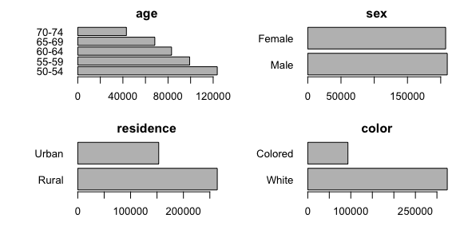

```r
plot(va.popn)
```

Function `dplot` produces lattice plots.

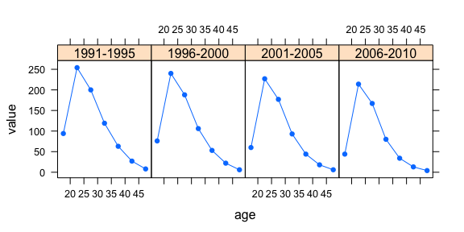

```r
dplot(~ age | period,
      data = ind.fert,
      midpoints = "age")
```

It can manipulate data in the background:

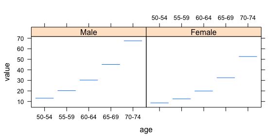

```r
dplot(~ age | sex,
      data = va.rates,
      weights = va.popn) # collapses 'residence' dimension
```

To use other graphing functions, such as `ggplot2` or `xyplot`, collapse the data down to the required dimensions, and then convert to a data.frame. The `midpoints` replaces intervals with their midpoints, which can lead to nicer plots.

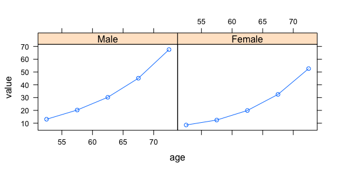

```r
va.rates.collapsed <- collapseDimension(va.rates,
                                        margin = c("age", "sex"),
                                        weights = va.popn)
va.rates.df <- as.data.frame(va.rates.collapsed,
                             direction = "long",
                             midpoints = "age")
lattice::xyplot(value ~ age | sex,
                data = va.rates.df,
                type = "b")
```

# Uncertainty

Demographic arrays use a simulation-based approach to representing uncertainty. An array can contain multiple versions of the same set of rates or counts, with quantities that are more uncertain varying more across versions Alternative versions are distinguished using a dimension with dimtype `"iterations"`.

```r
tfr <- demdata::waikato.tfr
tfr <- Values(tfr, dimscales = c(year = "Intervals"))
summary(tfr)
```

```
#>
#> name:     year      iteration
#> length:   19        100
#> dimtype:  time      iteration
#> dimscale: Intervals Iterations
#> first:    1997      1
#> last:     2015      100
#>
#>    Min. 1st Qu.  Median    Mean 3rd Qu.    Max.
#>   1.983   2.117   2.169   2.194   2.261   2.473
```

```r
subarray(tfr, iteration <= 5)
```

```
#> An object of class "Values"
#>
#> name:     year      iteration
#> length:   19        5
#> dimtype:  time      iteration
#> dimscale: Intervals Iterations
#> first:    1997      1
#> last:     2015      5
#>
#>       iteration
#> year          1        2        3        4        5
#>   1997 2.138156 2.150548 2.134826 2.113705 2.083204
#>   1998 2.082190 2.070766 2.114445 2.137554 2.105848
#>   1999 2.160767 2.117289 2.157152 2.071509 2.125254
#>   2000 2.161467 2.171266 2.171518 2.208316 2.216906
#>   2001 2.122063 2.087963 2.144206 2.143327 2.090370
#>   2002 2.084844 2.057681 2.080821 2.051584 2.100329
#>   2003 2.097790 2.075710 2.092849 2.079933 2.059938
#>   2004 2.115658 2.150610 2.125751 2.146124 2.133986
#>   2005 2.127046 2.156781 2.233731 2.197723 2.212377
#>   2006 2.111897 2.102876 2.133341 2.130521 2.122550
#>   2007 2.286667 2.302176 2.298900 2.251137 2.282724
#>   2008 2.325205 2.398898 2.379573 2.325245 2.359789
#>   2009 2.390532 2.390110 2.381742 2.412271 2.429248
#>   2010 2.295468 2.369136 2.337683 2.281853 2.339841
#>   2011 2.261307 2.284530 2.250425 2.252984 2.243647
#>   2012 2.276837 2.199244 2.221867 2.220756 2.183365
#>   2013 2.152033 2.257434 2.228677 2.177876 2.171149
#>   2014 2.132609 2.117461 2.102644 2.187209 2.156382
#>   2015 2.220617 2.224368 2.270994 2.210355 2.207663
```

It can be helpful to think of an array with an iterations dimension as a collection of arrays, rather than as a single array. Consider what happens when taking the mean of an array with an iterations dimension.

```r
mean.tfr <- mean(tfr)
summary(mean.tfr)
```

```
#>
#> name:     iteration
#> length:   100
#> dimtype:  iteration
#> dimscale: Iterations
#> first:    1
#> last:     100
#>
#>    Min. 1st Qu.  Median    Mean 3rd Qu.    Max.
#>   2.174   2.188   2.195   2.194   2.199   2.211
```

```r
subarray(mean.tfr, iteration <= 5)
```

```
#> iteration
#>        1        2        3        4        5
#> 2.186482 2.193939 2.203218 2.189473 2.190767
```

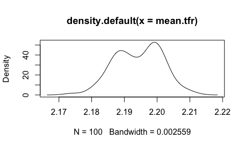

```r
density.mean.tfr <- density(mean.tfr)
plot(density.mean.tfr)
```

Summary measures of the variation across the iterations can be constructed using function `collapseIterations’:

```r
collapseIterations(tfr)
```

```
#> An object of class "Values"
#>
#> name:     year      quantile
#> length:   19        5
#> dimtype:  time      quantile
#> dimscale: Intervals Quantiles
#> first:    1997      0%
#> last:     2015      100%
#>
#>       quantile
#> year         0%      25%      50%      75%     100%
#>   1997 2.053199 2.090534 2.108107 2.123309 2.184941
#>   1998 2.022485 2.080500 2.095826 2.124812 2.155936
#>   1999 2.071509 2.117232 2.128896 2.149160 2.208204
#>   2000 2.114656 2.167413 2.178208 2.205116 2.255750
#>   2001 2.032050 2.079882 2.094792 2.122229 2.161628
#>   2002 1.997227 2.063857 2.079692 2.100446 2.147058
#>   2003 1.982720 2.048937 2.070686 2.092416 2.143391
#>   2004 2.099678 2.133131 2.150425 2.168504 2.228831
#>   2005 2.116835 2.151908 2.170373 2.191793 2.251646
#>   2006 2.065257 2.100702 2.123841 2.138235 2.177619
#>   2007 2.207749 2.250655 2.267710 2.287327 2.345368
#>   2008 2.282303 2.339242 2.362146 2.385254 2.429363
#>   2009 2.335211 2.385572 2.412384 2.430104 2.473229
#>   2010 2.281853 2.335539 2.352471 2.368611 2.416308
#>   2011 2.216732 2.265776 2.286095 2.306485 2.374829
#>   2012 2.177008 2.221231 2.245117 2.265227 2.320976
#>   2013 2.112714 2.167573 2.187857 2.212829 2.257434
#>   2014 2.088511 2.119913 2.145905 2.166414 2.209806
#>   2015 2.145480 2.201255 2.215303 2.231870 2.287777
```

To obtain different quantiles, supply a `prob` argument:

```r
collapseIterations(tfr, prob = c(0.025, 0.5, 0.975))
```

```
#> An object of class "Values"
#>
#> name:     year      quantile
#> length:   19        3
#> dimtype:  time      quantile
#> dimscale: Intervals Quantiles
#> first:    1997      2.5%
#> last:     2015      97.5%
#>
#>       quantile
#> year       2.5%      50%    97.5%
#>   1997 2.070297 2.108107 2.160585
#>   1998 2.047916 2.095826 2.152016
#>   1999 2.088146 2.128896 2.182240
#>   2000 2.134160 2.178208 2.237518
#>   2001 2.047232 2.094792 2.149905
#>   2002 2.023147 2.079692 2.137203
#>   2003 2.024675 2.070686 2.130955
#>   2004 2.102929 2.150425 2.207910
#>   2005 2.124160 2.170373 2.231465
#>   2006 2.072435 2.123841 2.167963
#>   2007 2.218494 2.267710 2.329436
#>   2008 2.307225 2.362146 2.415724
#>   2009 2.344602 2.412384 2.466463
#>   2010 2.298065 2.352471 2.390349
#>   2011 2.230723 2.286095 2.335679
#>   2012 2.195659 2.245117 2.298364
#>   2013 2.133784 2.187857 2.233689
#>   2014 2.092805 2.145905 2.194770
#>   2015 2.159012 2.215303 2.266718
```

Although quantiles are the most common way to summarise iterations, `collapseIterations` accepts any summary functions, including customised ones,

```r
collapseIterations(tfr, FUN = mean)
```

```
#> An object of class "Values"
#>
#> name:     year
#> length:   19
#> dimtype:  time
#> dimscale: Intervals
#> first:    1997
#> last:     2015
#>
#> year
#>     1997     1998     1999     2000     2001     2002     2003     2004
#> 2.109222 2.100790 2.132043 2.183158 2.099967 2.080453 2.071903 2.151681
#>     2005     2006     2007     2008     2009     2010     2011     2012
#> 2.173479 2.120201 2.268179 2.362227 2.408792 2.350176 2.285925 2.243312
#>     2013     2014     2015
#> 2.188698 2.144978 2.215789
```

```r
meanAndCI <- function(x) {
  mean <- mean(x)
  sd <- sd(x)
  lower <- mean - 2*sd
  upper <- mean + 2*sd
  c(mean = mean, lower = lower, upper = upper)
}
collapseIterations(tfr, FUN = meanAndCI)
```

```
#> An object of class "Values"
#>
#> name:     year      meanAndCI
#> length:   19        3
#> dimtype:  time      state
#> dimscale: Intervals Categories
#> first:    1997      mean
#> last:     2015      upper
#>
#>       meanAndCI
#> year       mean    lower    upper
#>   1997 2.109222 2.057570 2.160874
#>   1998 2.100790 2.040567 2.161012
#>   1999 2.132043 2.081968 2.182119
#>   2000 2.183158 2.127790 2.238527
#>   2001 2.099967 2.043352 2.156583
#>   2002 2.080453 2.022701 2.138205
#>   2003 2.071903 2.013381 2.130426
#>   2004 2.151681 2.098563 2.204799
#>   2005 2.173479 2.113757 2.233200
#>   2006 2.120201 2.069613 2.170789
#>   2007 2.268179 2.211312 2.325046
#>   2008 2.362227 2.299843 2.424610
#>   2009 2.408792 2.347278 2.470306
#>   2010 2.350176 2.298785 2.401567
#>   2011 2.285925 2.226987 2.344864
#>   2012 2.243312 2.184119 2.302505
#>   2013 2.188698 2.130475 2.246922
#>   2014 2.144978 2.086473 2.203482
#>   2015 2.215789 2.164992 2.266585
```

In practice, we probably don’t want to display so many digits,

```r
quant.tfr <- collapseIterations(tfr, prob = c(0.025, 0.5, 0.975))
round(quant.tfr, digits = 2)
```

```
#> An object of class "Values"
#>
#> name:     year      quantile
#> length:   19        3
#> dimtype:  time      quantile
#> dimscale: Intervals Quantiles
#> first:    1997      2.5%
#> last:     2015      97.5%
#>
#>       quantile
#> year   2.5%  50% 97.5%
#>   1997 2.07 2.11  2.16
#>   1998 2.05 2.10  2.15
#>   1999 2.09 2.13  2.18
#>   2000 2.13 2.18  2.24
#>   2001 2.05 2.09  2.15
#>   2002 2.02 2.08  2.14
#>   2003 2.02 2.07  2.13
#>   2004 2.10 2.15  2.21
#>   2005 2.12 2.17  2.23
#>   2006 2.07 2.12  2.17
#>   2007 2.22 2.27  2.33
#>   2008 2.31 2.36  2.42
#>   2009 2.34 2.41  2.47
#>   2010 2.30 2.35  2.39
#>   2011 2.23 2.29  2.34
#>   2012 2.20 2.25  2.30
#>   2013 2.13 2.19  2.23
#>   2014 2.09 2.15  2.19
#>   2015 2.16 2.22  2.27
```

Function `dplot` automatically displays 2.5%, 25%, 50%, 75%, and 97.5% quantiles,

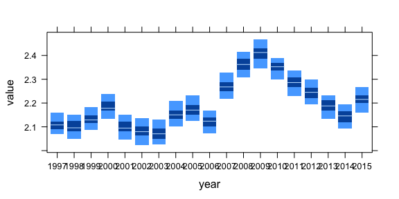

```r
dplot(~ year,
      data = tfr)
```

Alternative quantiles can be specified using the `prob` argument,

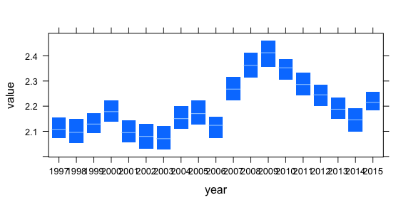

```r
dplot(~ year,
      data = tfr,
      prob = c(0.05, 0.5, 0.95))
```

Operations on quantiles often do not make sense,

```r
mean(quant.tfr)
```

```
#> Error in mean(quant.tfr): 'x' has dimension with dimtype "quantile"
```

Instead, it may be better perform the calculations on the original iterations, and then calculate quantiles

```r
mean.tfr <- mean(tfr)
collapseIterations(mean.tfr,
                   prob = c(0.025, 0.5, 0.975))
```

```
#> An object of class "Values"
#>
#> name:     quantile
#> length:   3
#> dimtype:  quantile
#> dimscale: Quantiles
#> first:    2.5%
#> last:     97.5%
#>
#> quantile
#>     2.5%      50%    97.5%
#> 2.180970 2.194557 2.206854
```

# Features under development

## Demographic accounts

The biggest feature currently missing from `dembase` is classes and methods for demographic accounts. These will be added in stages over 2016-2017.

## Rewrite of `dplot`

`dplot` will be rewritten to handle nonstandard evaluation better, and to add some extra features, such as improved plotting of categorical variables, and improved overlays.

## `dapply`

It would be useful to have a version of `apply` specialised for demographic arrays.

## Demographic indices and measures

The demographic literature has many indices for describing demographic data, such as indices measuring population ageing. These will gradually be added to the package.

## Functions for manipulating metadata

Manipulating metadata in a way that avoids creating invalid arrays is tricky, but more functions for doing so are needed.

## Functions for cleaning data before creating demographic arrays

More functions for cleaning data, eg for creating age labels, would be useful.

## Specialised dimscales for quarterly and monthly data

A dimscale is needed that knows what to do with measurements such as `2016Q1`, `2016Q2`, `2016Q3`.